# IODS course project

Juho Pirhonen

# Dimensionality reduction exercise

## The data

### 1. Load and describe data

Code for data wrangling can be found [here](https://github.com/Juhous/IODS-project/blob/master/create_human.R)

```r
#Hidden
source("helper_functions.R")
library(magrittr)
library(GGally)
library(stringr)
library(knitr)
library(kableExtra)
library(ggplot2)
library(tidyr)
library(MASS)
library(dplyr)
```

```r
df <- read.csv(file = "data/human.csv", row.names = 1)
glimpse(df)
```

```
## Observations: 155
## Variables: 8
## $ eduRatio      <dbl> 1.0072389, 0.9968288, 0.9834369, 0.9886128, 0.96...
## $ labRatio      <dbl> 0.8908297, 0.8189415, 0.8251001, 0.8840361, 0.82...
## $ expEdu        <dbl> 17.5, 20.2, 15.8, 18.7, 17.9, 16.5, 18.6, 16.5, ...
## $ lifeExp       <dbl> 81.6, 82.4, 83.0, 80.2, 81.6, 80.9, 80.9, 79.1, ...
## $ GNIC          <dbl> 64.992, 42.261, 56.431, 44.025, 45.435, 43.919, ...
## $ matMort       <int> 4, 6, 6, 5, 6, 7, 9, 28, 11, 8, 6, 4, 8, 4, 27, ...
## $ adolBirthRate <dbl> 7.8, 12.1, 1.9, 5.1, 6.2, 3.8, 8.2, 31.0, 14.5, ...
## $ reprParl      <dbl> 39.6, 30.5, 28.5, 38.0, 36.9, 36.9, 19.9, 19.4, ...
```

### 2. Graphical overview of data

```r
#Hidden
df %>% summaryKable() %>%
  kable("html", align = "rrr", caption = "Data variable summary") %>%
  kable_styling(bootstrap_options = c("hover", "condensed")) %>%
  scroll_box(width = "100%")
```

Data variable summary

|  | eduRatio | labRatio | expEdu | lifeExp | GNIC | matMort | adolBirthRate | reprParl |
| --- | --- | --- | --- | --- | --- | --- | --- | --- |
| Min | 0.172 | 0.186 | 5.400 | 49.000 | 1.123 | 1.000 | 0.600 | 0.000 |
| 1st Q | 0.726 | 0.598 | 11.250 | 66.300 | 5.275 | 11.500 | 12.650 | 12.400 |
| Median | 0.938 | 0.753 | 13.500 | 74.200 | 13.054 | 49.000 | 33.600 | 19.300 |
| Mean | 0.853 | 0.707 | 13.176 | 71.654 | 46.496 | 149.084 | 47.159 | 20.912 |
| 3rd Q | 0.997 | 0.854 | 15.200 | 77.250 | 27.256 | 190.000 | 71.950 | 27.950 |
| Max | 1.497 | 1.038 | 20.200 | 83.500 | 908.000 | 1100.000 | 204.800 | 57.500 |

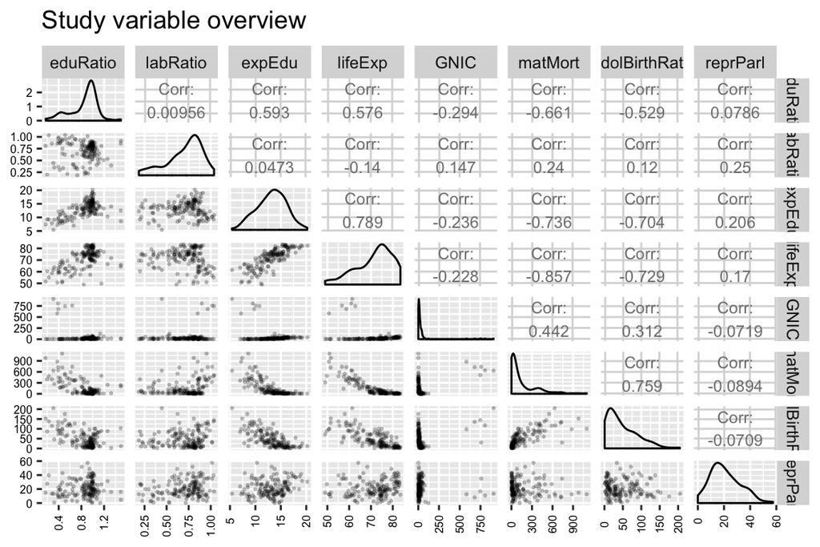

```r
# Hidden
ggpairs(df,
  title = "Study variable overview",
  upper = list(continuous = wrap("cor", size = 3)),
  lower = list(
    continuous = wrap("points", alpha = .2, size = .4),
    combo = wrap("facethist", bins = 20))) +
theme(axis.text.x = element_text(
                  angle = 90,
                  color = "black",
                  size = 6,
                  vjust = .5),
      axis.text.y = element_text(color = "black", size = 6))
```

Many of the variables are normally distributed, but with eduRatio, GNIC and matMort, some problems might arise if normality is assumed.

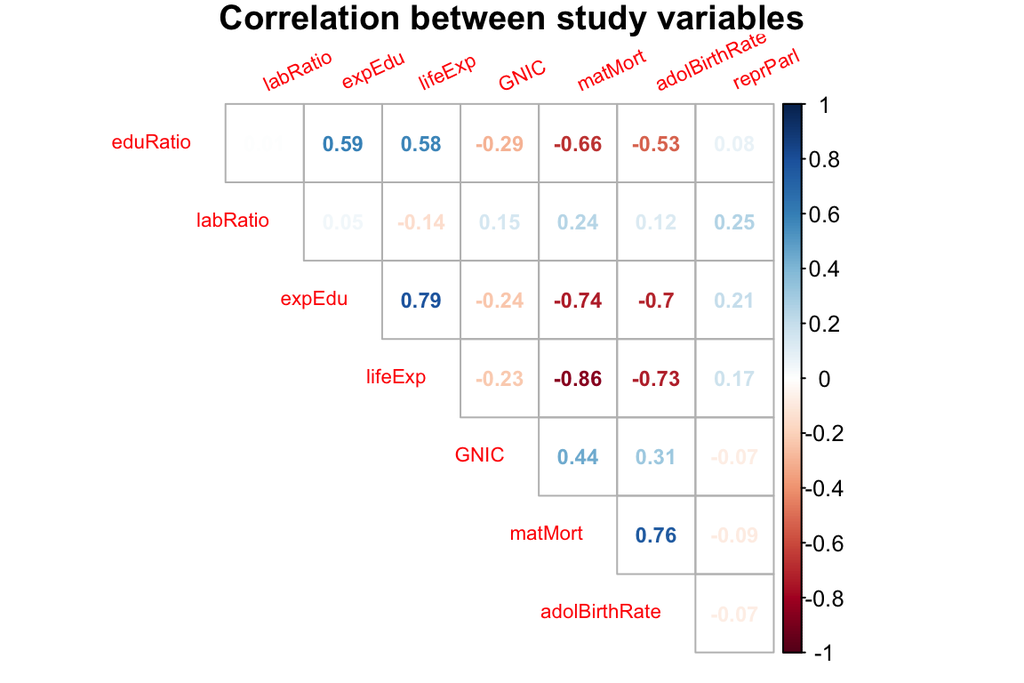

```r
#Hidden
cor(df, use = "pairwise.complete.obs") %>%
  corrplot::corrplot(method = "number", type = "upper",
                     tl.pos = "td", tl.srt = 25,
                     tl.offset = 1, tl.cex = .7,
                     number.cex = .75,
                     title = "Correlation between study variables",
                     mar=c(0,0,1,0),
                     diag = F)
```

According to above plot, education correlates strongly and positively with life expectancy, and negatively with maternal mortality and adolescent births. Maternal mortality correlates strongly and negatively with education ratio, life expectancy and education.

## Principal component analysis

### 3. PCA on non-normalized data

```r
pca <- prcomp(df)
pca %>% summary()
```

```
## Importance of components:
##                            PC1      PC2      PC3      PC4     PC5     PC6
## Standard deviation     227.566 121.2798 26.48071 11.47526 3.89773 1.60859
## Proportion of Variance   0.769   0.2184  0.01041  0.00196 0.00023 0.00004
## Cumulative Proportion    0.769   0.9874  0.99778  0.99974 0.99996 1.00000
##                           PC7    PC8
## Standard deviation     0.1915 0.1598
## Proportion of Variance 0.0000 0.0000
## Cumulative Proportion  1.0000 1.0000
```

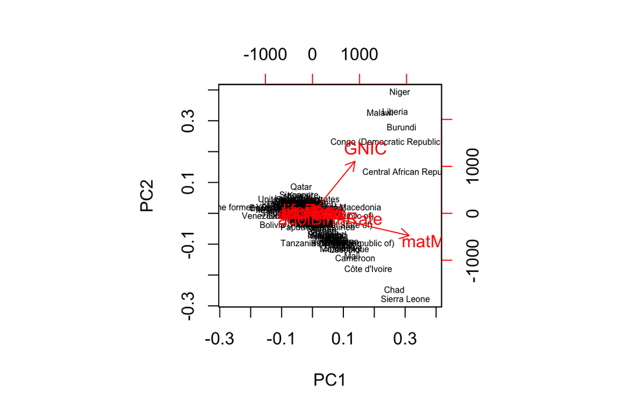

```r
#Hidden
biplot(pca, choices = 1:2, cex = c(.5,1))
```

Based on this plot, it seems tahat GNI per capita and maternal mortality are the most essential explanatory components of this data set.

### 4. PCA on normalized data

```r
df_scaled <- scale(df)
pca_scaled <- prcomp(df_scaled)
pca_scaled %>% summary
```

```
## Importance of components:
##                           PC1    PC2    PC3     PC4     PC5     PC6
## Standard deviation     1.9970 1.1465 0.9439 0.85645 0.69002 0.53246
## Proportion of Variance 0.4985 0.1643 0.1114 0.09169 0.05952 0.03544
## Cumulative Proportion  0.4985 0.6628 0.7742 0.86585 0.92536 0.96080
##                            PC7     PC8
## Standard deviation     0.46511 0.31184
## Proportion of Variance 0.02704 0.01216
## Cumulative Proportion  0.98784 1.00000
```

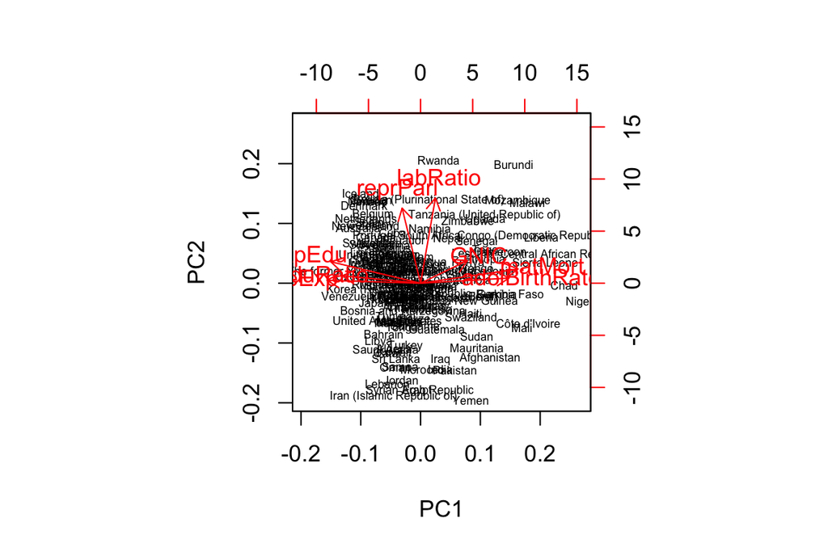

```r
#Hidden
biplot(pca_scaled, choices = 1:2, cex = c(.5,1))
```

According to scaled data, there is much more variation to what variables explain most of the variance in the data. Here, PC1 explains 50% of variation and most important determinary variables are maternal mortality, life expectancy and so forth. PC2 only explains 16%, and the most significant variables are labour ratio and parliamentary representation.

### 5. Interpret differences

```r
rbind(summary(pca)$importance[2,], summary(pca_scaled)$importance[2,]) %>%
  as.data.frame(row.names = c("orig", "scaled"))
```

```
##            PC1     PC2     PC3     PC4     PC5     PC6     PC7     PC8
## orig   0.76896 0.21841 0.01041 0.00196 0.00023 0.00004 0.00000 0.00000
## scaled 0.49849 0.16430 0.11137 0.09169 0.05952 0.03544 0.02704 0.01216
```

The total explained variance decreases with the scaled data. Still, only 3 principal components explain 77% of the variance in the data, and with 5 >90% of variance is explained.

```r
orig <- abs(pca$rotation) %*% summary(pca)$importance[2,]
scaled <- abs(pca_scaled$rotation) %*% summary(pca_scaled)$importance[2,]
cbind(orig, scaled) %>% data.frame() %>%
  rename(orig = X1, scaled = X2) %>% round(3) %>% t
```

```
##        eduRatio labRatio expEdu lifeExp  GNIC matMort adolBirthRate
## orig      0.001    0.000  0.008   0.029 0.507   0.784         0.129
## scaled    0.298    0.242  0.313   0.308 0.288   0.286         0.289
##        reprParl
## orig      0.006
## scaled    0.267
```

We can study the how much of the PCA-variance is explained by a variable as shown above. So, we calculate the importance_of_PC*absolute_value_for_variable, and sum this value across PCs for any given variable. From the results, it becomes clear that maternal mortality and GNI per capita were crudely overrepresented in the non-scaled data, most likely because of their high absolute range. With scaled data, the amount of explained variation is distributed fairly equally within variables.

## 6. MCA with tea dataset

```r
library(FactoMineR)
data(tea)
df <- tea

mca <- df %>% select(breakfast, friends, resto, Tea, Sport) %>%
  MCA(graph = FALSE)
mca %>% summary
```

```
##
## Call:
## MCA(X = ., graph = FALSE)
##
##
## Eigenvalues
##                        Dim.1   Dim.2   Dim.3   Dim.4   Dim.5   Dim.6
## Variance               0.268   0.235   0.213   0.174   0.160   0.149
## % of var.             22.370  19.550  17.778  14.522  13.358  12.421
## Cumulative % of var.  22.370  41.920  59.698  74.221  87.579 100.000
##
## Individuals (the 10 first)
##                  Dim.1    ctr   cos2    Dim.2    ctr   cos2    Dim.3
## 1             |  0.529  0.348  0.198 | -0.982  1.371  0.684 |  0.302
## 2             |  0.529  0.348  0.198 | -0.982  1.371  0.684 |  0.302
## 3             | -0.753  0.704  0.517 |  0.256  0.093  0.060 | -0.242
## 4             |  0.367  0.167  0.130 |  0.372  0.197  0.133 |  0.220
## 5             |  0.361  0.162  0.143 | -0.618  0.543  0.419 | -0.446
## 6             |  0.384  0.183  0.167 | -0.007  0.000  0.000 | -0.351
## 7             | -0.150  0.028  0.035 | -0.303  0.131  0.144 | -0.600
## 8             |  0.552  0.378  0.221 | -0.372  0.196  0.100 |  0.397
## 9             |  0.361  0.162  0.143 | -0.618  0.543  0.419 | -0.446
## 10            |  0.513  0.326  0.167 | -0.603  0.517  0.231 |  0.873
##                  ctr   cos2
## 1              0.143  0.065 |
## 2              0.143  0.065 |
## 3              0.091  0.053 |
## 4              0.075  0.046 |
## 5              0.310  0.218 |
## 6              0.193  0.140 |
## 7              0.563  0.563 |
## 8              0.246  0.114 |
## 9              0.310  0.218 |
## 10             1.190  0.485 |
##
## Categories (the 10 first)
##                   Dim.1     ctr    cos2  v.test     Dim.2     ctr    cos2
## breakfast     |  -0.031   0.034   0.001  -0.515 |  -0.769  24.200   0.546
## Not.breakfast |   0.029   0.032   0.001   0.515 |   0.710  22.339   0.546
## friends       |  -0.459  10.250   0.397 -10.893 |   0.264   3.885   0.131
```

[output cut: 11 more lines]

```
## Not.friends    -6.270 |   0.233   1.767   0.029   2.937 |
## Not.resto       0.938 |  -0.161   1.782   0.072  -4.646 |
## resto          -0.938 |   0.449   4.985   0.072   4.646 |
## black          -7.663 |   1.270  37.305   0.528  12.567 |
## Earl Grey       2.510 |  -0.457  12.585   0.376 -10.608 |
## green           6.714 |  -0.177   0.322   0.004  -1.073 |
## Not.sportsman   7.792 |   0.787  23.390   0.418  11.182 |
##
## Categorical variables (eta2)
##                 Dim.1 Dim.2 Dim.3
## breakfast     | 0.001 0.546 0.012 |
## friends       | 0.397 0.131 0.029 |
## resto         | 0.509 0.003 0.072 |
## Tea           | 0.435 0.290 0.536 |
## Sport         | 0.000 0.203 0.418 |
```

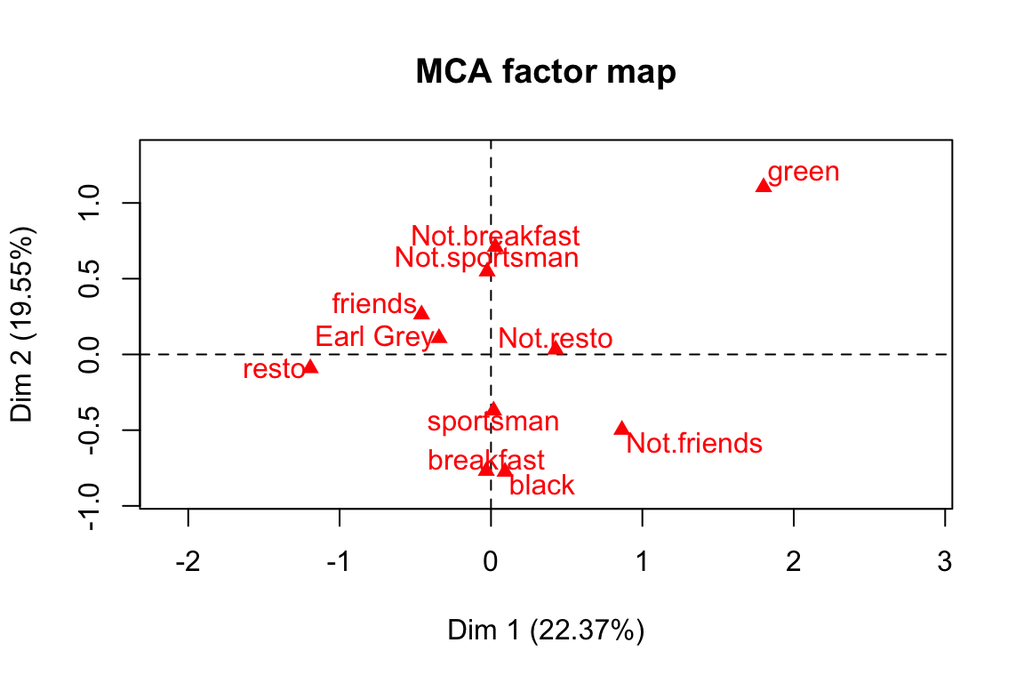

```r
#Hidden
mca %>% plot(invisible=c("ind"))
```